# Lymph node position variation for rectal cancer patients treated with long course radiotherapy: Supplementary data analysis

Dennis Tideman Arp

Ane L. Appelt

Rasmus Froberg Brøndum

Rasa Mikalone

Martin Skovmos Nielsen

Laurids Østergaard Poulsen

29/05/2024

Read and transform data

```r
data <- read_tsv("../ExternalData/Data_lymphnodes_141223.txt") %>%
  mutate(Patient = factor(sub("Pt", "#", Patient), levels = paste0("#", 1:14)),
         patient_node = factor(sub("Pt", "#", sub(" MR[0-9]", "", Unq_ID)),
                               levels = paste0(rep(paste0("#", 1:14), each = 8),"_", 1:8)),
         `Pretreat/during` = factor(`Pretreat/during`, levels = c("Pretreat", "During")),
         Rel_bladder = Rel_bladder / 100,
         Baseline_bladder = Baseline_bladder / 100,
         Shift_LR = Shift_X * 10,
         Shift_AP = Shift_Y * 10,
         Shift_CC = Shift_Z * 10,
         Shift_LR_GTV = Shift_X_GTV * 10,
         Shift_AP_GTV = Shift_Y_GTV * 10,
         Shift_CC_GTV = Shift_Z_GTV * 10,
         Location_plot = case_when(Location == "Pre" ~ "Presacral",
                                   Location == "LN"  ~ "Lateral nodes",
                                   Location == "Meso" ~ "Mesorectum"))
```

Compare the shifs for bony and soft tissue match

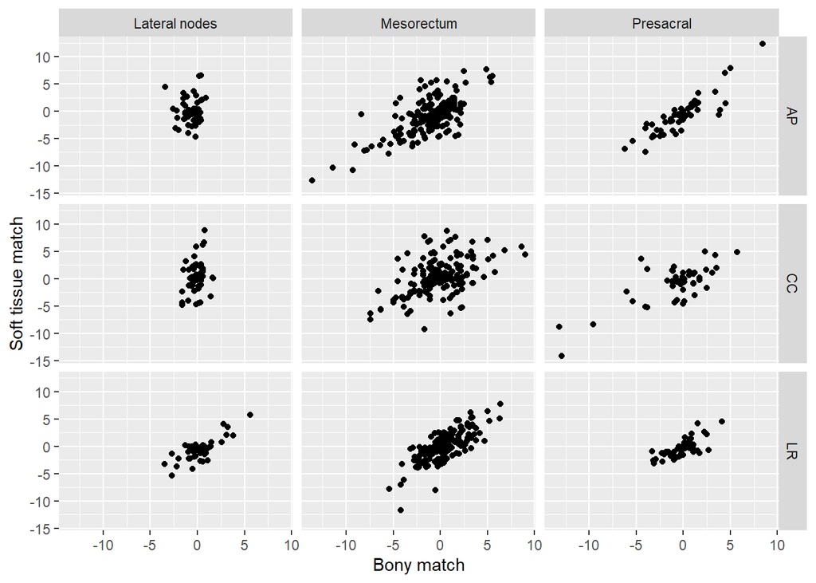

```r
bind_rows(data.frame(Location = data$Location_plot, Shift = data$Shift_LR, Shift_GTV = data$Shift_LR_GTV, Direction = "LR"),
          data.frame(Location = data$Location_plot, Shift = data$Shift_AP, Shift_GTV = data$Shift_AP_GTV, Direction = "AP"),
          data.frame(Location = data$Location_plot, Shift = data$Shift_CC, Shift_GTV = data$Shift_CC_GTV, Direction = "CC")) %>%
  ggplot(aes(x = Shift, y = Shift_GTV)) +
  geom_point() +
  xlab("Bony match") +
  ylab("Soft tissue match") +
  facet_grid(cols = vars(Location), rows = vars(Direction))
```

# Position variation relative to bony structures

## Visualize data

First we try to plot the data for each patient and Shift direction

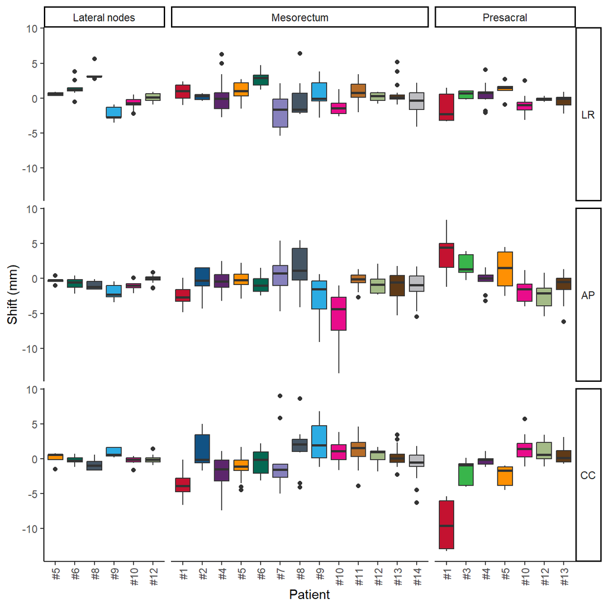

```r
fig1 <- data %>%
  dplyr::select(Patient, Location_plot, Shift_LR:Shift_CC) %>%
  pivot_longer(cols = Shift_LR:Shift_CC) %>%
  mutate(name = factor(sub("Shift_","", name), levels = c("LR", "AP", "CC"))) %>%
ggplot(aes(x = as.factor(Patient), y = value, fill = as.factor(Patient))) +
  geom_boxplot() +
  xlab("Patient") +
  ylab("Shift (mm)") +
  scale_fill_discrete(name = "Patient") +
  #theme_bw() +
  theme_classic() +
  facet_grid(rows = vars(name), cols = vars(Location_plot), space = "free_x", scales = "free_x") +
  theme(legend.position = "none", axis.text.x = element_text(angle = 90, vjust = 0.5, hjust=1),
        strip.text.y.right = element_text(angle = 0)) +
  scale_fill_manual(values = BloodCol)

fig1
```

```r
ggsave(plot = fig1, filename = "../Output/fig1.pdf")
```

Then we plot the data for individual nodes

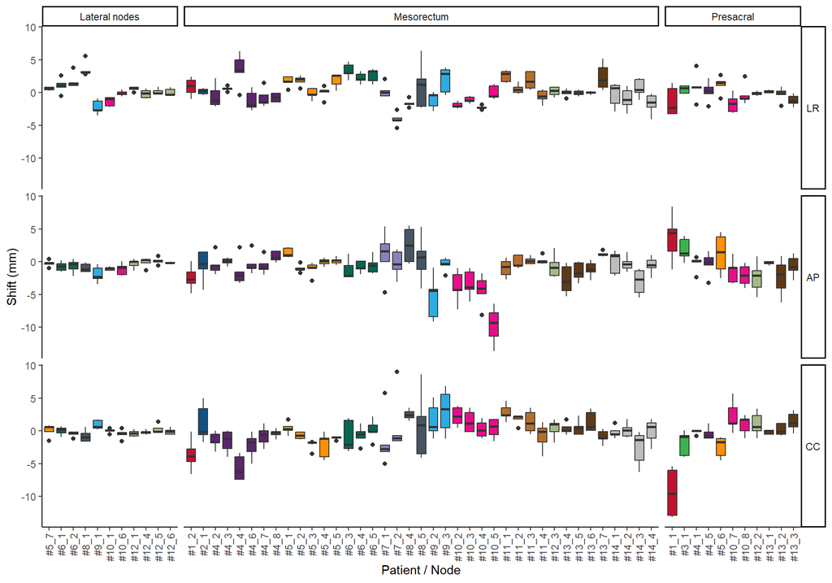

```r
fig2 <- data %>% dplyr::select(Patient, patient_node, Location_plot, Shift_LR:Shift_CC) %>%
  pivot_longer(cols = Shift_LR:Shift_CC) %>%
  mutate(name = factor(sub("Shift_","", name), levels = c("LR", "AP", "CC"))) %>%
ggplot(aes(x = as.factor(patient_node), y = value, fill = as.factor(Patient))) +
  geom_boxplot() +
  xlab("Patient / Node") +
  ylab("Shift (mm)") +
  scale_fill_discrete(name = "Patient") +
  theme_classic() +
  #theme_bw() +
  facet_grid(rows = vars(name), cols = vars(Location_plot), space = "free_x", scales = "free_x") +
  theme(legend.position = "none", axis.text.x = element_text(angle = 90, vjust = 0.5, hjust=1),
        strip.text.y.right = element_text(angle = 0)) +
  scale_fill_manual(values = BloodCol)

fig2
```

```r
ggsave(plot = fig2, filename = "../Output/fig2.pdf")
```

## Systematic and random var

```r
sys_rand_results <- list()
for(location in c("Combined", "LN", "Meso", "Pre")){
  for(direction in c("LR","AP","CC")){
    if(location == "Combined"){
      sys_rand_results[[paste0(location,"_",direction)]] <-
        lmer(as.formula(paste0("Shift_", direction, " ~ (1|Patient/patient_node)")), data)
    } else{
      sys_rand_results[[paste0(location,"_",direction)]] <-
        lmer(as.formula(paste0("Shift_", direction, " ~ (1|Patient/patient_node)")), data %>% filter(Location == location))
    }
  }
}
```

```r
summary_results <- data.frame("location" = NULL, "direction" = NULL, "M"=NULL, Patient_Node_SD = NULL, Patient_SD = NULL, "Sys_SD"=NULL, "Rand_SD" = NULL)
for(name in names(sys_rand_results)){
  location  <- str_split(name, "_")[[1]][1]
  direction <- str_split(name, "_")[[1]][2]
  #cat(location, direction, "\n")
  results <- broom.mixed::tidy(sys_rand_results[[name]])
  M        <- results$estimate[results$term == "(Intercept)"]
  Patient_Node_SD  <- results$estimate[results$group == "patient_node:Patient" & results$term == "sd__(Intercept)"]
  Patient_SD  <- results$estimate[results$group == "Patient" & results$term == "sd__(Intercept)"]
  Sys_SD  <- sqrt(sum(results$estimate[results$term == "sd__(Intercept)"])^2)
  Rand_SD <- results$estimate[results$term == "sd__Observation"]
  summary_results <- rbind(summary_results, data.frame(location, direction, M, Patient_Node_SD, Patient_SD, Sys_SD, Rand_SD))
}
```

```r
summary_results %>%
  pivot_longer(cols = M:Rand_SD) %>%
  pivot_wider(names_from = direction) %>%
  kable()
```

| location | name | LR | AP | CC |
| --- | --- | --- | --- | --- |
| Combined | M | 0.2010718 | -0.6743243 | -0.3872820 |
| Combined | Patient_Node_SD | 1.1650586 | 1.4291795 | 1.0566977 |
| Combined | Patient_SD | 0.7981935 | 0.9786845 | 1.8069732 |
| Combined | Sys_SD | 1.9632521 | 2.4078641 | 2.8636709 |
| Combined | Rand_SD | 1.2373878 | 1.7499741 | 1.8351158 |
| LN | M | 0.4556550 | -0.8218578 | -0.0777707 |
| LN | Patient_Node_SD | 0.3765537 | 0.0000000 | 0.1482093 |
| LN | Patient_SD | 1.8799117 | 0.5911154 | 0.4147415 |
| LN | Sys_SD | 2.2564654 | 0.5911154 | 0.5629508 |
| LN | Rand_SD | 0.7944124 | 0.7028148 | 0.6418723 |
| Meso | M | 0.2675469 | -1.0468786 | -0.0084708 |
| Meso | Patient_Node_SD | 1.2938815 | 1.3142692 | 0.9713403 |
| Meso | Patient_SD | 0.8592124 | 1.4895386 | 1.2306529 |
| Meso | Sys_SD | 2.1530939 | 2.8038078 | 2.2019931 |
| Meso | Rand_SD | 1.3001927 | 1.8160538 | 2.0644052 |
| Pre | M | -0.1300072 | 0.1150739 | -1.5381713 |
| Pre | Patient_Node_SD | 0.4472965 | 0.0000000 | 0.0000000 |
| Pre | Patient_SD | 0.5663485 | 1.9273261 | 3.6762997 |
| Pre | Sys_SD | 1.0136450 | 1.9273261 | 3.6762997 |
| Pre | Rand_SD | 1.3660713 | 2.1588453 | 1.7674469 |

Model control

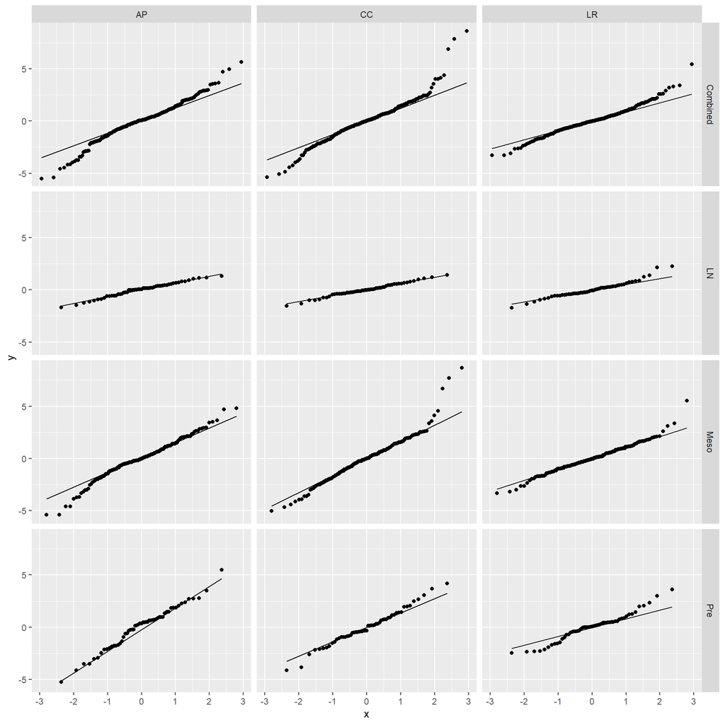

```r
sys_rand_results %>%
  purrr::map(~ {.x %>% residuals}) %>%
  bind_rows(.id = "id") %>%
  column_to_rownames("id") %>%
  t() %>%
  data.frame() %>%
  pivot_longer(everything()) %>%
  mutate(location = sapply(strsplit(name,"_"), function(x) x[[1]]),
         direction = sapply(strsplit(name,"_"), function(x) x[[2]])) %>%
  ggplot(aes(sample = value)) +
  stat_qq() +
  stat_qq_line() +
  facet_grid(cols = vars(direction), rows = vars(location))
```

## Effect of location

We test if the location of the nodes have an effect on the magnitude of the shift in either direction

```r
loc_results <- list()
for(direction in c("LR","AP","CC")){
  loc_results[[direction]] <-
    lmer(as.formula(paste0("Shift_", direction, " ~ Location + (1|Patient/patient_node)")), data)
}
```

We extract the estimates and p.values of the location effects. The model design uses contrasts, i.e. “LN” is included in the intercept, and effects for “Meso” and “Pre” is given as the difference in mean compared to “LN”. Results indicate no significant difference in the average magnitude of the shift across the different locations for all directions.

```r
lapply(loc_results, broom.mixed::tidy) %>%
  bind_rows(.id = "Direction") %>%
  filter(effect == "fixed") %>%
  dplyr::select(Direction, estimate, term, p.value) %>%
  pivot_wider(names_from = "Direction", values_from = c("estimate", "p.value")) %>%
  dplyr::select(term, estimate_LR, p.value_LR, estimate_AP, p.value_AP, estimate_CC, p.value_CC) %>%
  kable()
```

| term | estimate_LR | p.value_LR | estimate_AP | p.value_AP | estimate_CC | p.value_CC |
| --- | --- | --- | --- | --- | --- | --- |
| (Intercept) | 0.2645534 | 0.5943285 | -0.1741210 | 0.7773523 | -0.8446492 | 0.2327226 |
| LocationMeso | -0.0085068 | 0.9864788 | -0.8031499 | 0.1914590 | 0.5896335 | 0.2789507 |
| LocationPre | -0.3256012 | 0.5974848 | 0.2386066 | 0.7498443 | 0.3815595 | 0.5661269 |

Model control

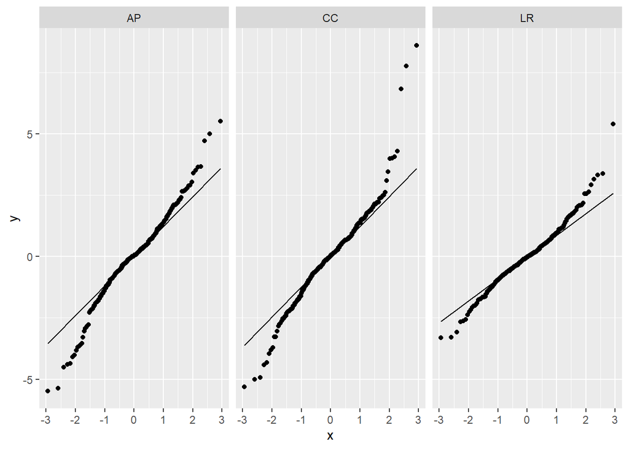

```r
loc_results %>%
  purrr::map(~ {.x %>% residuals}) %>%
  bind_rows(.id = "id") %>%
  column_to_rownames("id") %>%
  t() %>%
  data.frame() %>%
  pivot_longer(everything()) %>%
  ggplot(aes(sample = value)) +
  stat_qq() +
  stat_qq_line() +
  facet_wrap(~name, ncol = 3)
```

## Effect of Pretreat/During

We test if the radiation time (Pretreat / During) of the nodes have an effect on the magnitude of the shift in either direction

```r
predur_results <- list()
for(direction in c("LR","AP","CC")){
  predur_results[[direction]] <-
    lmer(as.formula(paste0("Shift_", direction, " ~ `Pretreat/during` + (1|Patient/patient_node)")), data)
}
```

We extract the estimates and p.values of the effects. The model design uses contrasts, i.e. “Pretreat” is included in the intercept, and the effect of “During” is given as the difference in mean compared to “Pretreat”. Results indicate a significant difference in the magnitude of the shift in the AP direction.

```r
lapply(predur_results, broom.mixed::tidy) %>%
  bind_rows(.id = "Direction") %>%
  filter(effect == "fixed") %>%
  dplyr::select(Direction, estimate, term, p.value) %>%
  pivot_wider(names_from = "Direction", values_from = c("estimate", "p.value")) %>%
  dplyr::select(term, estimate_LR, p.value_LR, estimate_AP, p.value_AP, estimate_CC, p.value_CC) %>%
  kable()
```

| term | estimate_LR | p.value_LR | estimate_AP | p.value_AP | estimate_CC | p.value_CC |
| --- | --- | --- | --- | --- | --- | --- |
| (Intercept) | 0.1266453 | 0.6737760 | -0.1479231 | 0.6938437 | -0.4067930 | 0.4653648 |
| `Pretreat/during`During | 0.1240437 | 0.3921726 | -0.8773224 | 0.0000130 | 0.0325137 | 0.8798785 |

Model control

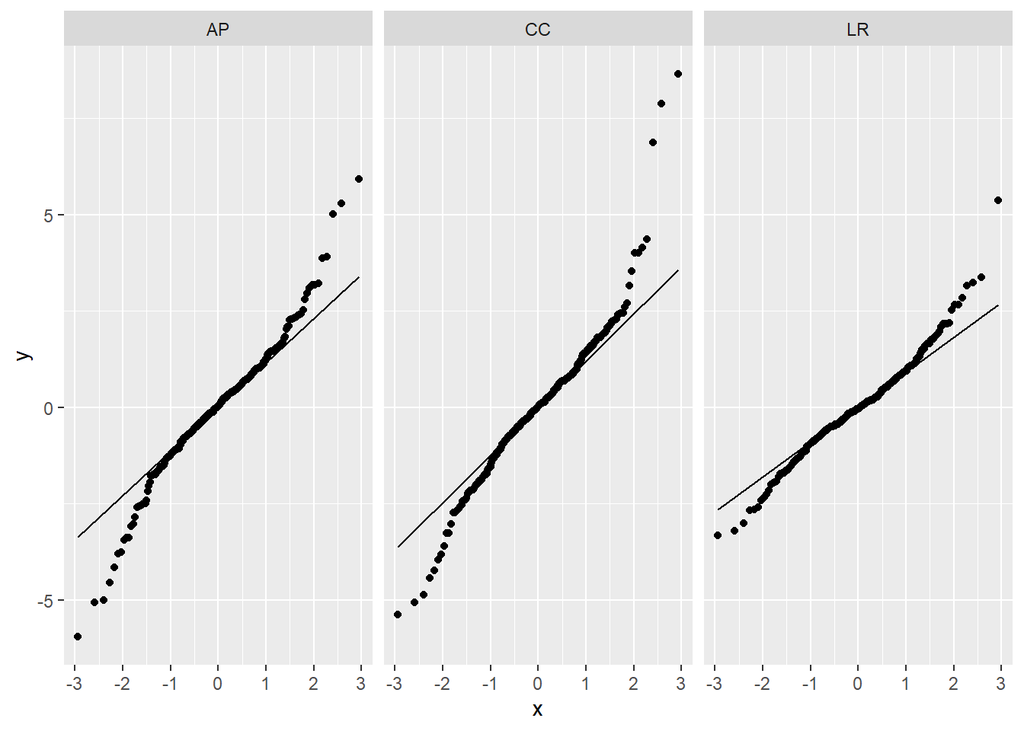

```r
predur_results %>%
  purrr::map(~ {.x %>% residuals}) %>%
  bind_rows(.id = "id") %>%
  column_to_rownames("id") %>%
  t() %>%
  data.frame() %>%
  pivot_longer(everything()) %>%
  ggplot(aes(sample = value)) +
  stat_qq() +
  stat_qq_line() +
  facet_wrap(~name, ncol = 3)
```

## Effect of initial bladder volume

We test if the baseline bladder volume has an effect on the magnitude of the shift in either direction

```r
baseline_bladder_results <- list()
for(direction in c("LR","AP","CC")){
  baseline_bladder_results[[direction]] <-
    lmer(as.formula(paste0("Shift_", direction, " ~ Baseline_bladder + (1|Patient/patient_node)")), data)
}
```

We extract the estimates and p.values of the effects. We see no significant effect in either direction.

```r
lapply(baseline_bladder_results, broom.mixed::tidy) %>%
  bind_rows(.id = "Direction") %>%
  filter(effect == "fixed") %>%
  dplyr::select(Direction, estimate, term, p.value) %>%
  pivot_wider(names_from = "Direction", values_from = c("estimate", "p.value")) %>%
  dplyr::select(term, estimate_LR, p.value_LR, estimate_AP, p.value_AP, estimate_CC, p.value_CC) %>%
  kable()
```

| term | estimate_LR | p.value_LR | estimate_AP | p.value_AP | estimate_CC | p.value_CC |
| --- | --- | --- | --- | --- | --- | --- |
| (Intercept) | -0.3992842 | 0.5117812 | -1.3139761 | 0.1071471 | -0.3653089 | 0.7683312 |
| Baseline_bladder | 0.3496578 | 0.2697830 | 0.3712344 | 0.3525229 | -0.0142343 | 0.9817177 |

Model control

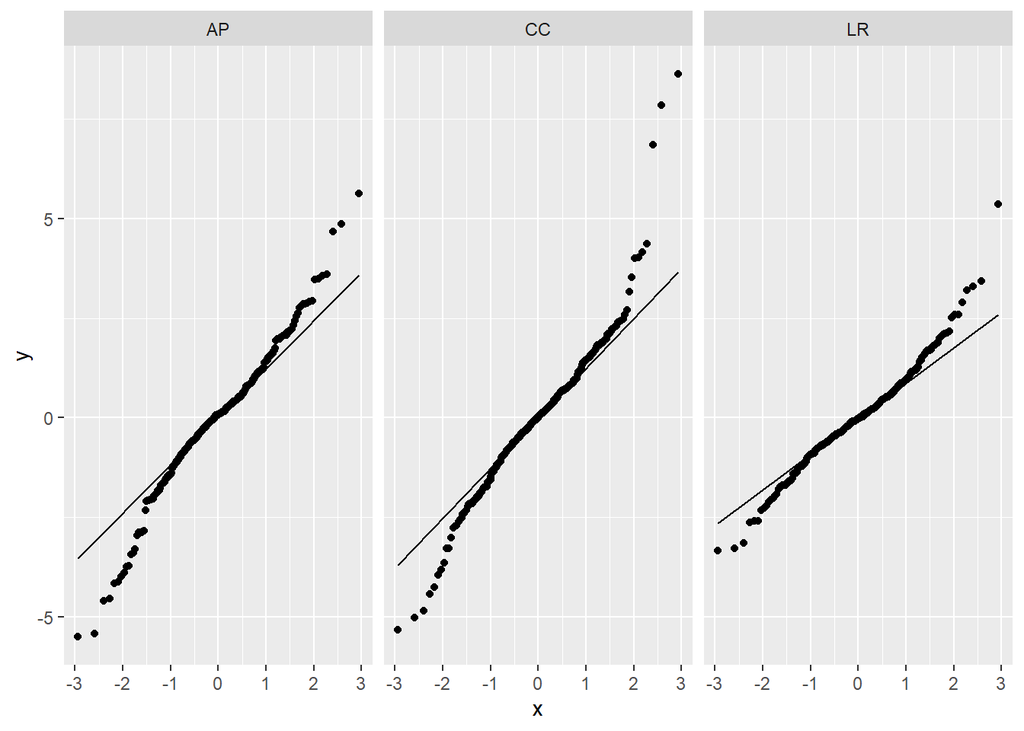

```r
baseline_bladder_results %>%
  purrr::map(~ {.x %>% residuals}) %>%
  bind_rows(.id = "id") %>%
  column_to_rownames("id") %>%
  t() %>%
  data.frame() %>%
  pivot_longer(everything()) %>%
  ggplot(aes(sample = value)) +
  stat_qq() +
  stat_qq_line() +
  facet_wrap(~name, ncol = 3)
```

## Effect of relative bladder

Here we investigate the effect of the relative volume of the bladder on the magnitude of the shift in either direction and location. First we do a plot of Rel_bladder vs shift, and add simple regression lines for each patient/node combination.

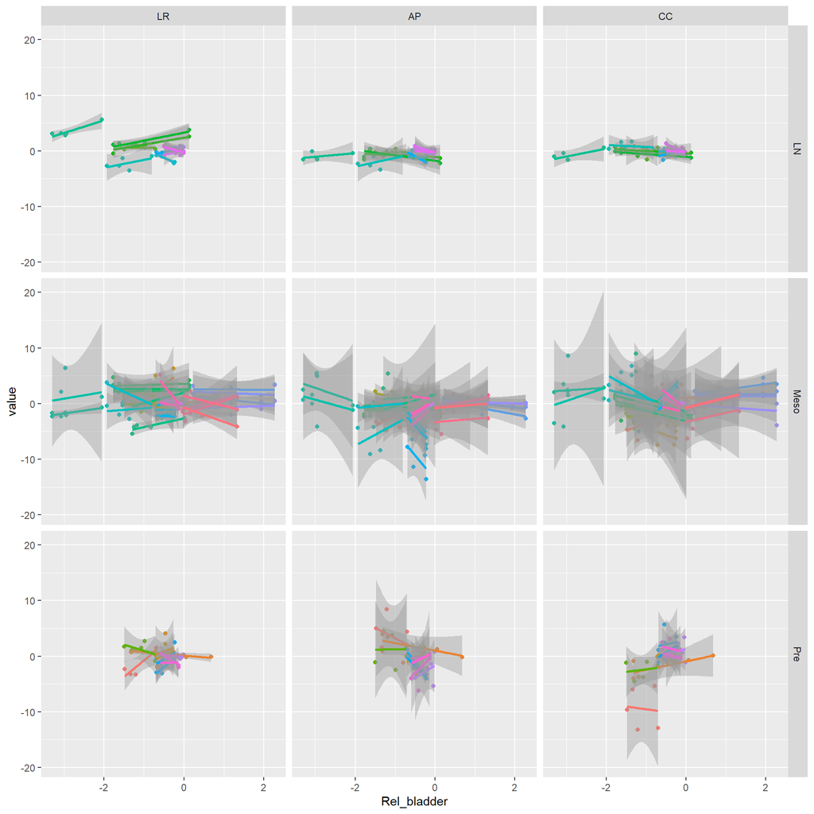

```r
data %>% dplyr::select(Patient, patient_node, Location, Rel_bladder, Shift_LR:Shift_CC) %>%
  pivot_longer(cols = Shift_LR:Shift_CC) %>%
  mutate(name = factor(sub("Shift_","", name), levels = c("LR", "AP", "CC"))) %>%
  ggplot(aes(x = Rel_bladder, y = value, col = patient_node)) +
  geom_point() +
  stat_smooth(method = "lm",
              formula = y ~ x,
              geom = "smooth") +
  facet_grid(rows = vars(Location), cols = vars(name)) +
  theme(legend.position = "none")
```

We test the effect of the relative fill of the bladder combined and stratified by location and direction using the same nested mixed model as before, i.e. each patient/node gets an indvidual intercept.

```r
#bladder_strat_results <- list()
#for(location in c("LN", "Meso", "Pre")){
#  for(direction in c("LR","AP","CC")){
#    bladder_strat_results[[paste0(location,"_",direction)]] <-
#     lmer(as.formula(paste0("Shift_", direction, " ~ Rel_bladder + (1|Patient/patient_node)")), data %>% filter(Location == location))
#  }
#}

bladder_strat_results <- list()
for(location in c("Combined", "LN", "Meso", "Pre")){
  for(direction in c("LR","AP","CC")){
    if(location == "Combined"){
      bladder_strat_results[[paste0(location,"_",direction)]] <-
        lmer(as.formula(paste0("Shift_", direction, " ~ Rel_bladder + (1|Patient/patient_node)")), data)
    } else{
      bladder_strat_results[[paste0(location,"_",direction)]] <-
        lmer(as.formula(paste0("Shift_", direction, " ~ Rel_bladder + (1|Patient/patient_node)")), data %>% filter(Location == location))
    }
  }
}
```

Results show a tendency for the relative bladder volume to increase the magnitude of the shift in the LR direction for LN, and decrease the magnitude of the shift in the AP direction for Pre. For the combined model we see no significance. Effect sizes are given in mm/(100 ml).

```r
lapply(bladder_strat_results, broom.mixed::tidy) %>%
  bind_rows(.id = "test") %>%
  filter(term == "Rel_bladder") %>%
  mutate(location = sapply(strsplit(test,"_"), function(x) x[[1]]),
         direction = sapply(strsplit(test,"_"), function(x) x[[2]])) %>%
  dplyr::select(location, direction, estimate, p.value) %>%
  pivot_wider(names_from = "direction", values_from = c("estimate", "p.value")) %>%
  dplyr::select(location, estimate_LR, p.value_LR, estimate_AP, p.value_AP, estimate_CC, p.value_CC) %>%
  kable()
```

| location | estimate_LR | p.value_LR | estimate_AP | p.value_AP | estimate_CC | p.value_CC |
| --- | --- | --- | --- | --- | --- | --- |
| Combined | 0.1210409 | 0.4384574 | -0.2126829 | 0.3163010 | -0.0600586 | 0.8035887 |
| LN | 1.0306305 | 0.0000757 | -0.1629788 | 0.4385251 | -0.0433228 | 0.8072436 |
| Meso | -0.0145070 | 0.9386773 | -0.0864561 | 0.7448413 | -0.1855976 | 0.5018719 |
| Pre | 0.2362193 | 0.6491276 | -2.0525819 | 0.0160118 | 1.2142631 | 0.1067566 |

Model control

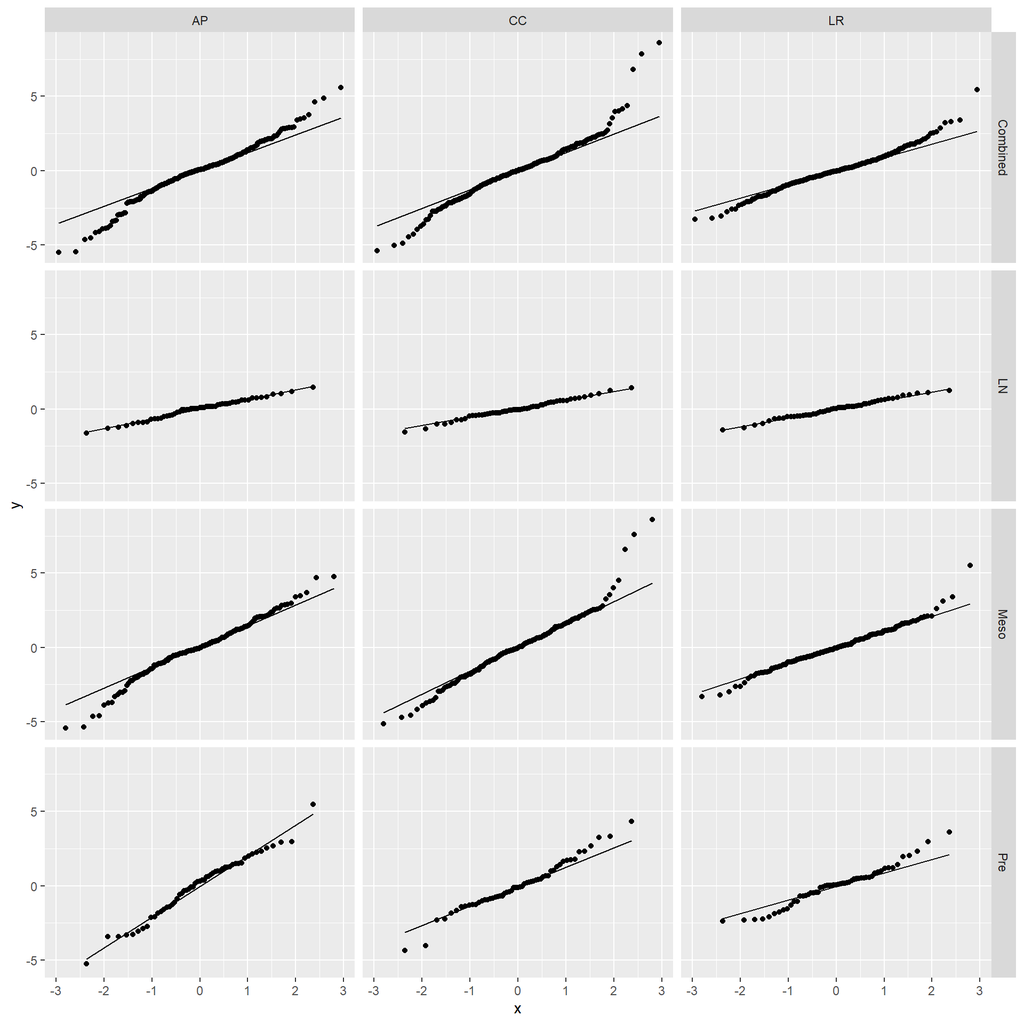

```r
bladder_strat_results %>%
  purrr::map(~ {.x %>% residuals}) %>%
  bind_rows(.id = "id") %>%
  column_to_rownames("id") %>%
  t() %>%
  data.frame() %>%
  pivot_longer(everything()) %>%
  mutate(location = sapply(strsplit(name,"_"), function(x) x[[1]]),
         direction = sapply(strsplit(name,"_"), function(x) x[[2]])) %>%
  ggplot(aes(sample = value)) +
  stat_qq() +
  stat_qq_line() +
  facet_grid(cols = vars(direction), rows = vars(location))
```

## Multivariable model

```r
## model for bladder vs shift with interaction on location. Seems to disrupt the effect on shift_x in pre, seen in the stratified model.
bladder_comb_results <- list()
for(direction in c("LR","AP","CC")){
    bladder_comb_results[[paste0(direction)]] <-
      lmer(as.formula(paste0("Shift_", direction, " ~ Rel_bladder*Location + Baseline_bladder + `Pretreat/during` + (1|Patient/patient_node)")), data)

}

multires <- lapply(bladder_comb_results, broom.mixed::tidy)
kable(multires$LR, caption = "Results of multivariate model for LR")
```

Results of multivariate model for LR

| effect | group | term | estimate | std.error | statistic | df | p.value |
| --- | --- | --- | --- | --- | --- | --- | --- |
| fixed | NA | (Intercept) | -0.4483684 | 0.8267699 | -0.5423134 | 25.21826 | 0.5923632 |
| fixed | NA | Rel_bladder | 0.5403734 | 0.3721851 | 1.4518942 | 272.99282 | 0.1476793 |
| fixed | NA | LocationMeso | -0.2665242 | 0.6190836 | -0.4305142 | 80.93659 | 0.6679659 |
| fixed | NA | LocationPre | -0.4169470 | 0.7475431 | -0.5577565 | 86.44987 | 0.5784522 |
| fixed | NA | Baseline_bladder | 0.5902214 | 0.3386970 | 1.7426239 | 16.55700 | 0.0999399 |
| fixed | NA | `Pretreat/during`During | 0.1602233 | 0.1465819 | 1.0930633 | 239.20257 | 0.2754656 |
| fixed | NA | Rel_bladder:LocationMeso | -0.3383002 | 0.3902254 | -0.8669354 | 234.24621 | 0.3868645 |
| fixed | NA | Rel_bladder:LocationPre | -0.0975009 | 0.6150846 | -0.1585162 | 296.27146 | 0.8741580 |
| ran_pars | patient_node:Patient | sd__(Intercept) | 1.2238461 | NA | NA | NA | NA |
| ran_pars | Patient | sd__(Intercept) | 0.7225389 | NA | NA | NA | NA |
| ran_pars | Residual | sd__Observation | 1.2332279 | NA | NA | NA | NA |

```r
kable(multires$AP, caption = "Results of multivariate model for AP")
```

Results of multivariate model for AP

| effect | group | term | estimate | std.error | statistic | df | p.value |
| --- | --- | --- | --- | --- | --- | --- | --- |
| fixed | NA | (Intercept) | 0.3782706 | 1.0819588 | 0.3496165 | 26.50545 | 0.7293892 |
| fixed | NA | Rel_bladder | 0.2279167 | 0.4817259 | 0.4731253 | 248.20310 | 0.6365396 |
| fixed | NA | LocationMeso | -1.2175390 | 0.7473219 | -1.6292029 | 85.03680 | 0.1069692 |
| fixed | NA | LocationPre | -0.9596202 | 0.8937768 | -1.0736688 | 87.64266 | 0.2859184 |
| fixed | NA | Baseline_bladder | 0.1445068 | 0.4643286 | 0.3112166 | 18.21203 | 0.7591702 |
| fixed | NA | `Pretreat/during`During | -0.9193817 | 0.2001493 | -4.5934798 | 240.11055 | 0.0000070 |
| fixed | NA | Rel_bladder:LocationMeso | -0.4942605 | 0.4966695 | -0.9951497 | 191.45429 | 0.3209195 |
| fixed | NA | Rel_bladder:LocationPre | -1.9714140 | 0.8088849 | -2.4371998 | 287.48609 | 0.0154080 |
| ran_pars | patient_node:Patient | sd__(Intercept) | 1.3021503 | NA | NA | NA | NA |
| ran_pars | Patient | sd__(Intercept) | 1.1231176 | NA | NA | NA | NA |
| ran_pars | Residual | sd__Observation | 1.6839764 | NA | NA | NA | NA |

```r
kable(multires$CC, caption = "Results of multivariate model for CC")
```

Results of multivariate model for CC

| effect | group | term | estimate | std.error | statistic | df | p.value |
| --- | --- | --- | --- | --- | --- | --- | --- |
| fixed | NA | (Intercept) | -0.3909911 | 1.3644571 | -0.2865544 | 17.12426 | 0.7778916 |
| fixed | NA | Rel_bladder | -0.0805933 | 0.4862616 | -0.1657406 | 205.42844 | 0.8685241 |
| fixed | NA | LocationMeso | 0.2747550 | 0.6956535 | 0.3949596 | 74.62727 | 0.6939993 |
| fixed | NA | LocationPre | 1.3354288 | 0.8212550 | 1.6260831 | 79.68728 | 0.1078805 |
| fixed | NA | Baseline_bladder | -0.2008768 | 0.6373896 | -0.3151554 | 13.54160 | 0.7574477 |
| fixed | NA | `Pretreat/during`During | -0.0020683 | 0.2192924 | -0.0094315 | 240.01235 | 0.9924827 |
| fixed | NA | Rel_bladder:LocationMeso | -0.2737144 | 0.4851239 | -0.5642154 | 128.79906 | 0.5735887 |
| fixed | NA | Rel_bladder:LocationPre | 1.9314657 | 0.8320990 | 2.3211970 | 248.98927 | 0.0210843 |
| ran_pars | patient_node:Patient | sd__(Intercept) | 0.9528923 | NA | NA | NA | NA |
| ran_pars | Patient | sd__(Intercept) | 1.8512367 | NA | NA | NA | NA |
| ran_pars | Residual | sd__Observation | 1.8441888 | NA | NA | NA | NA |

# Position variation relative to primary tumor

## Visualize data

First we try to plot the data for each patient and Shift direction

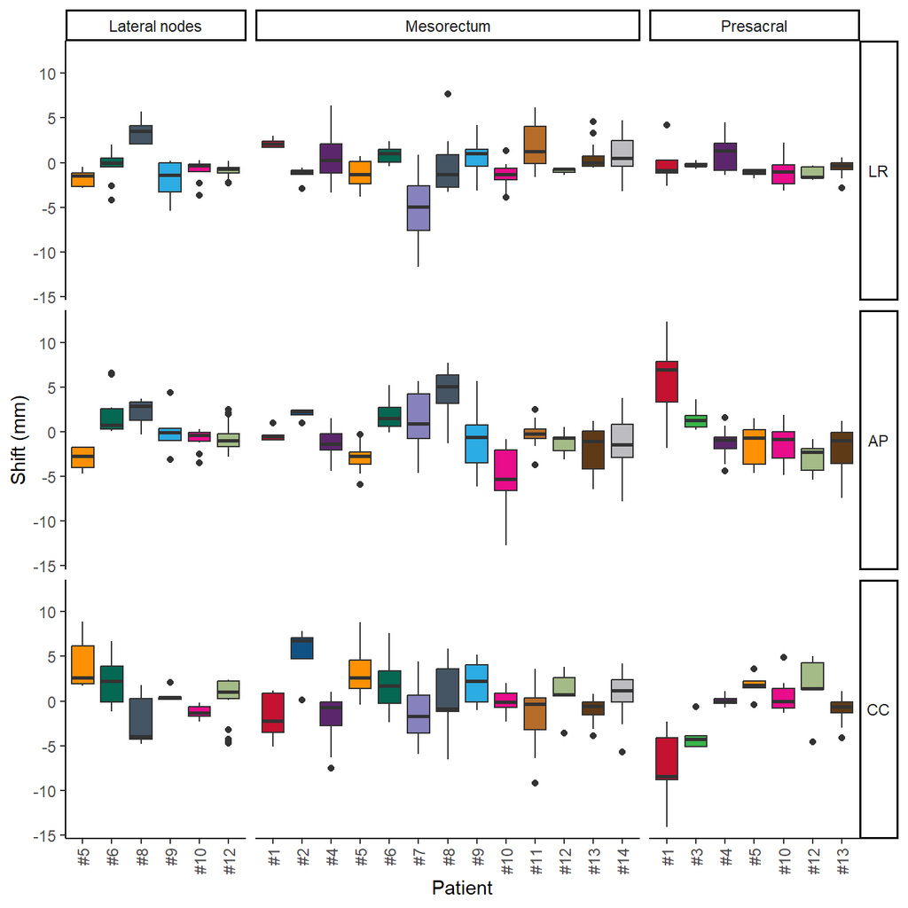

```r
data %>% dplyr::select(Patient, Location_plot, Shift_LR_GTV:Shift_CC_GTV) %>%
  pivot_longer(cols = Shift_LR_GTV:Shift_CC_GTV) %>%
  mutate(name = factor(sapply(str_split(name, "_"), function(x) x[2]), levels = c("LR", "AP", "CC"))) %>%
ggplot(aes(x = as.factor(Patient), y = value, fill = as.factor(Patient))) +
  geom_boxplot() +
  xlab("Patient") +
  ylab("Shift (mm)") +
  scale_fill_discrete(name = "Patient") +
  #theme_bw() +
  theme_classic() +
  facet_grid(rows = vars(name), cols = vars(Location_plot), space = "free_x", scales = "free_x") +
  theme(legend.position = "none", axis.text.x = element_text(angle = 90, vjust = 0.5, hjust=1),
        strip.text.y.right = element_text(angle = 0)) +
  scale_fill_manual(values = BloodCol)
```

Then we plot the data for individual nodes

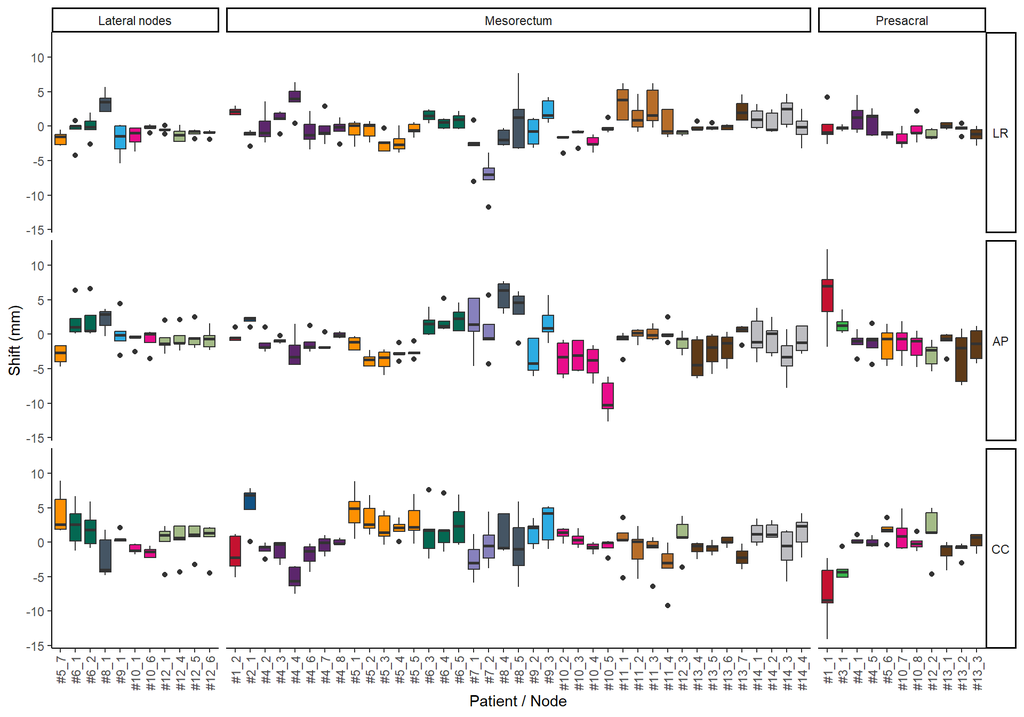

```r
data %>% dplyr::select(Patient, patient_node, Location_plot, Shift_LR_GTV:Shift_CC_GTV) %>%
  pivot_longer(cols = Shift_LR_GTV:Shift_CC_GTV) %>%
  mutate(name = factor(sapply(str_split(name, "_"), function(x) x[2]), levels = c("LR", "AP", "CC"))) %>%
ggplot(aes(x = as.factor(patient_node), y = value, fill = as.factor(Patient))) +
  geom_boxplot() +
  xlab("Patient / Node") +
  ylab("Shift (mm)") +
  scale_fill_discrete(name = "Patient") +
  #theme_bw() +
  theme_classic() +
  facet_grid(rows = vars(name), cols = vars(Location_plot), space = "free_x", scales = "free_x") +
  theme(legend.position = "none", axis.text.x = element_text(angle = 90, vjust = 0.5, hjust=1),
        strip.text.y.right = element_text(angle = 0)) +
  scale_fill_manual(values = BloodCol)
```

## Systematic and random var

We use a similar model for estimating the systematic and random variance

```r
sys_rand_results <- list()
for(location in c("Combined", "LN", "Meso", "Pre")){
  for(direction in c("LR","AP","CC")){
    if(location == "Combined"){
      sys_rand_results[[paste0(location,"_",direction)]] <-
        lmer(as.formula(paste0("Shift_", direction, "_GTV ~ (1|Patient/patient_node)")), data)
    } else{
      sys_rand_results[[paste0(location,"_",direction)]] <-
        lmer(as.formula(paste0("Shift_", direction, "_GTV ~ (1|Patient/patient_node)")), data %>% filter(Location == location))
    }
  }
}
```

```r
summary_results <- data.frame("location" = NULL, "direction" = NULL, "M"=NULL, Patient_Node_SD = NULL, Patient_SD = NULL, "Sys_SD"=NULL, "Rand_SD" = NULL)
for(name in names(sys_rand_results)){
  location  <- str_split(name, "_")[[1]][1]
  direction <- str_split(name, "_")[[1]][2]
  #cat(location, direction, "\n")
  results <- broom.mixed::tidy(sys_rand_results[[name]])
  M        <- results$estimate[results$term == "(Intercept)"]
  Patient_Node_SD  <- results$estimate[results$group == "patient_node:Patient" & results$term == "sd__(Intercept)"]
  Patient_SD  <- results$estimate[results$group == "Patient" & results$term == "sd__(Intercept)"]
  Sys_SD  <- sqrt(sum(results$estimate[results$term == "sd__(Intercept)"])^2)
  Rand_SD <- results$estimate[results$term == "sd__Observation"]
  summary_results <- rbind(summary_results, data.frame(location, direction, M, Patient_Node_SD, Patient_SD, Sys_SD, Rand_SD))
}
```

```r
summary_results %>%
  pivot_longer(cols = M:Rand_SD) %>%
  pivot_wider(names_from = direction) %>%
  kable()
```

| location | name | LR | AP | CC |
| --- | --- | --- | --- | --- |
| Combined | M | -0.2717650 | -0.1162171 | -0.0361357 |
| Combined | Patient_Node_SD | 1.0775641 | 1.3152756 | 0.8151997 |
| Combined | Patient_SD | 1.4395725 | 1.9131843 | 2.2620974 |
| Combined | Sys_SD | 2.5171366 | 3.2284599 | 3.0772971 |
| Combined | Rand_SD | 1.6623952 | 2.1772837 | 2.3860259 |
| LN | M | -0.4199141 | -0.0084884 | 0.6535926 |
| LN | Patient_Node_SD | 0.0000000 | 0.0000000 | 0.0000000 |
| LN | Patient_SD | 1.8853376 | 1.7554829 | 2.0785069 |
| LN | Sys_SD | 1.8853376 | 1.7554829 | 2.0785069 |
| LN | Rand_SD | 1.3275719 | 1.8435798 | 2.3356596 |
| Meso | M | -0.1853583 | -0.5154813 | 0.4862730 |
| Meso | Patient_Node_SD | 1.2058598 | 1.2535963 | 0.7943324 |
| Meso | Patient_SD | 1.5743252 | 2.2235336 | 1.7825555 |
| Meso | Sys_SD | 2.7801851 | 3.4771299 | 2.5768879 |
| Meso | Rand_SD | 1.8013233 | 2.0756091 | 2.4121591 |
| Pre | M | -0.4360391 | -0.3053377 | -1.1587052 |
| Pre | Patient_Node_SD | 0.2707124 | 0.0000000 | 0.0000000 |
| Pre | Patient_SD | 0.6023547 | 2.6858341 | 3.1918241 |
| Pre | Sys_SD | 0.8730670 | 2.6858341 | 3.1918241 |
| Pre | Rand_SD | 1.4189305 | 2.6386131 | 2.1843062 |

Model control

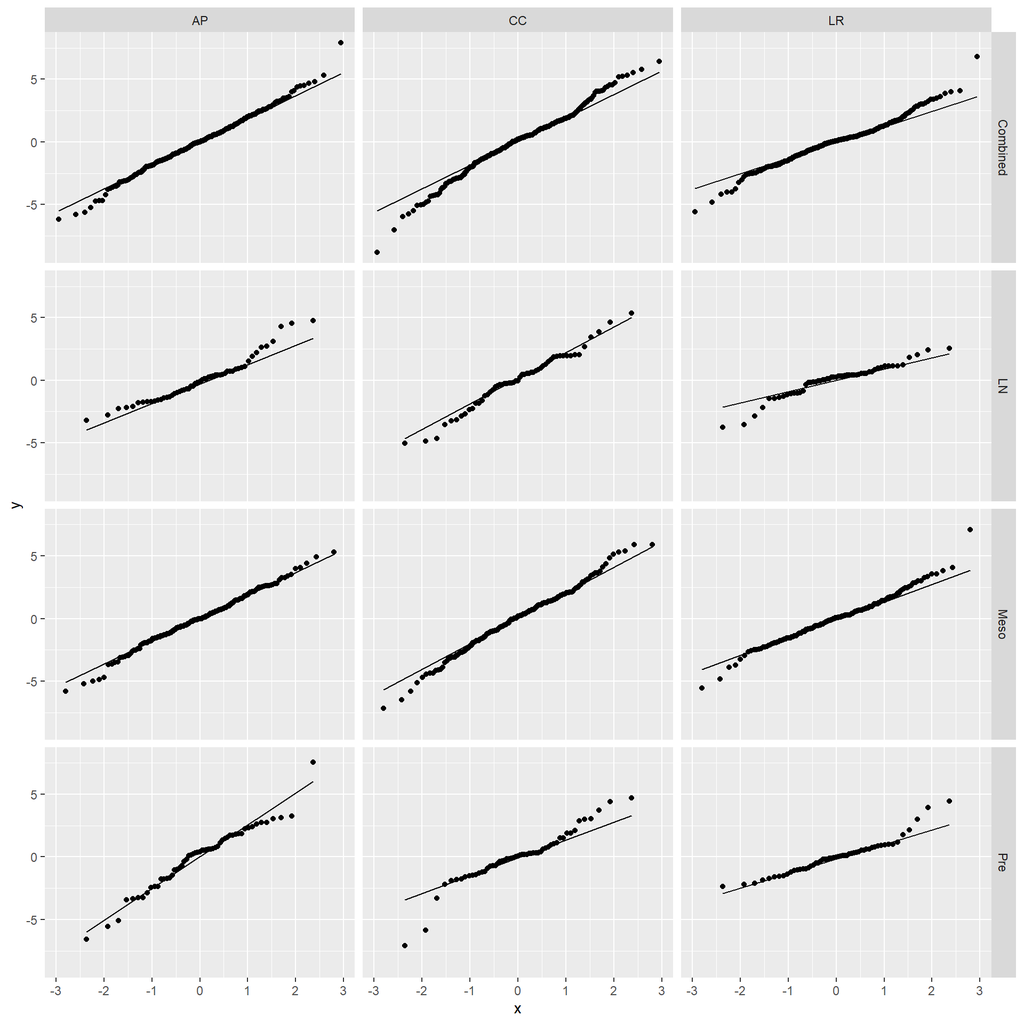

```r
sys_rand_results %>%
  purrr::map(~ {.x %>% residuals}) %>%
  bind_rows(.id = "id") %>%
  column_to_rownames("id") %>%
  t() %>%
  data.frame() %>%
  pivot_longer(everything()) %>%
  mutate(location = sapply(strsplit(name,"_"), function(x) x[[1]]),
         direction = sapply(strsplit(name,"_"), function(x) x[[2]])) %>%
  ggplot(aes(sample = value)) +
  stat_qq() +
  stat_qq_line() +
  facet_grid(cols = vars(direction), rows = vars(location))
```

## Effect of location

We test if the location of the nodes have an effect on the magnitude of the shift in either direction

```r
loc_results <- list()
for(direction in c("LR","AP","CC")){
  loc_results[[direction]] <-
    lmer(as.formula(paste0("Shift_", direction, "_GTV ~ Location + (1|Patient/patient_node)")), data)
}
```

We extract the estimates and p.values of the location effects. The model design uses contrasts, i.e. “LN” is included in the intercept, and effects for “Meso” and “Pre” is given as the difference in mean compared to “LN”. Results indicate no significant difference in the magnitude of the shift across the different locations for all directions.

```r
lapply(loc_results, broom.mixed::tidy) %>%
  bind_rows(.id = "Direction") %>%
  filter(effect == "fixed") %>%
  dplyr::select(Direction, estimate, term, p.value) %>%
  pivot_wider(names_from = "Direction", values_from = c("estimate", "p.value")) %>%
  dplyr::select(term, estimate_LR, p.value_LR, estimate_AP, p.value_AP, estimate_CC, p.value_CC) %>%
  kable()
```

| term | estimate_LR | p.value_LR | estimate_AP | p.value_AP | estimate_CC | p.value_CC |
| --- | --- | --- | --- | --- | --- | --- |
| (Intercept) | -0.3422084 | 0.5804914 | 0.5798518 | 0.4613936 | -0.5184555 | 0.5160629 |
| LocationMeso | 0.1407248 | 0.7910635 | -1.0232053 | 0.1136012 | 0.6225594 | 0.2584632 |
| LocationPre | -0.1141043 | 0.8608102 | -0.0675561 | 0.9312341 | 0.3983822 | 0.5539322 |

Model control

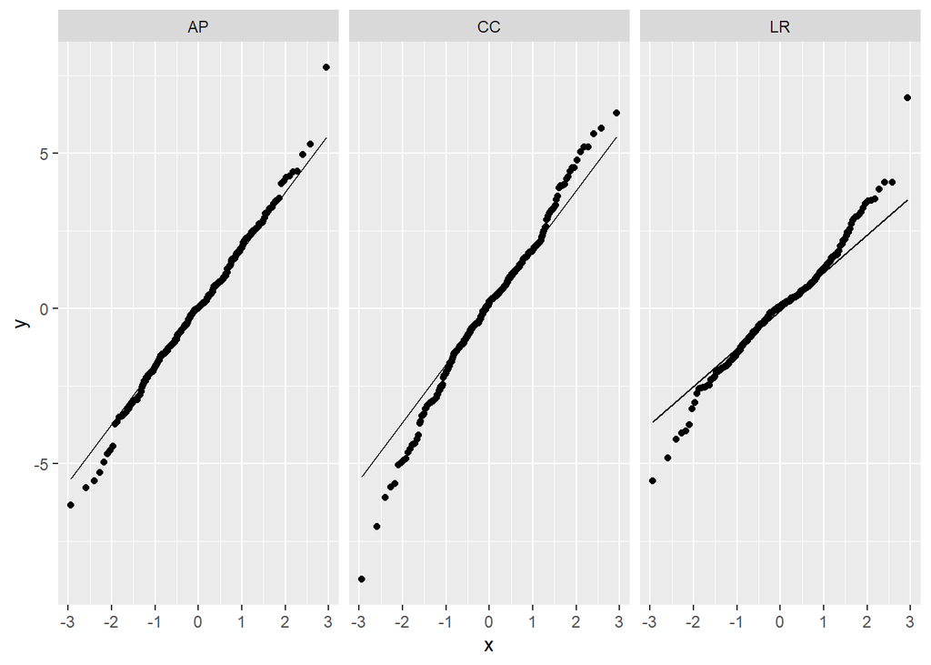

```r
loc_results %>%
  purrr::map(~ {.x %>% residuals}) %>%
  bind_rows(.id = "id") %>%
  column_to_rownames("id") %>%
  t() %>%
  data.frame() %>%
  pivot_longer(everything()) %>%
  ggplot(aes(sample = value)) +
  stat_qq() +
  stat_qq_line() +
  facet_wrap(~name, ncol = 3)
```

## Effect of Pretreat/During

We test if the radiation time (Pretreat / During) of the nodes have an effect on the magnitude of the shift in either direction

```r
predur_results <- list()
for(direction in c("LR","AP","CC")){
  predur_results[[direction]] <-
    lmer(as.formula(paste0("Shift_", direction, "_GTV ~ `Pretreat/during` + (1|Patient/patient_node)")), data)
}
```

We extract the estimates and p.values of the effects. The model design uses contrasts, i.e. “Pretreat” is included in the intercept, and the effect of “During” is given as the difference in mean compared to “Pretreat”. Results indicate a significant difference in the magnitude of the shift in the AP and CC directions.

```r
lapply(predur_results, broom.mixed::tidy) %>%
  bind_rows(.id = "Direction") %>%
  filter(effect == "fixed") %>%
  dplyr::select(Direction, estimate, term, p.value) %>%
  pivot_wider(names_from = "Direction", values_from = c("estimate", "p.value")) %>%
  dplyr::select(term, estimate_LR, p.value_LR, estimate_AP, p.value_AP, estimate_CC, p.value_CC) %>%
  kable()
```

| term | estimate_LR | p.value_LR | estimate_AP | p.value_AP | estimate_CC | p.value_CC |
| --- | --- | --- | --- | --- | --- | --- |
| (Intercept) | -0.2125844 | 0.6431913 | 0.5296932 | 0.3816160 | -0.5323658 | 0.4353069 |
| `Pretreat/during`During | -0.0986339 | 0.6127151 | -1.0765027 | 0.0000173 | 0.8270492 | 0.0028483 |

Model control

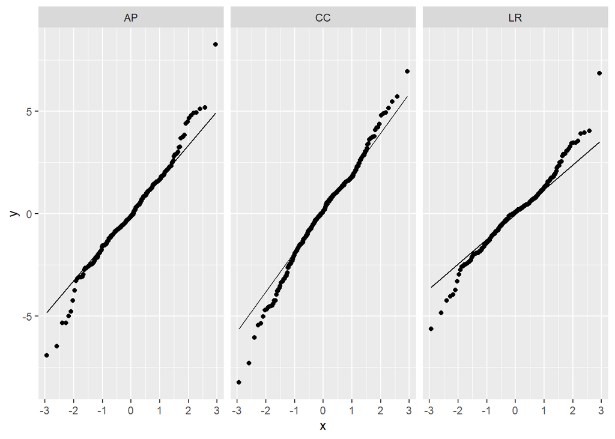

```r
predur_results %>%
  purrr::map(~ {.x %>% residuals}) %>%
  bind_rows(.id = "id") %>%
  column_to_rownames("id") %>%
  t() %>%
  data.frame() %>%
  pivot_longer(everything()) %>%
  ggplot(aes(sample = value)) +
  stat_qq() +
  stat_qq_line() +
  facet_wrap(~name, ncol = 3)
```

## Effect of initial bladder volume

We test if the baseline bladder volume has an effect on the magnitude of the shift in either direction

```r
baseline_bladder_results <- list()
for(direction in c("LR","AP","CC")){
  baseline_bladder_results[[direction]] <-
    lmer(as.formula(paste0("Shift_", direction, "_GTV ~ Baseline_bladder + (1|Patient/patient_node)")), data)
}
```

We extract the estimates and p.values of the effects. We see no significant effect in either direction.

```r
lapply(baseline_bladder_results, broom.mixed::tidy) %>%
  bind_rows(.id = "Direction") %>%
  filter(effect == "fixed") %>%
  dplyr::select(Direction, estimate, term, p.value) %>%
  pivot_wider(names_from = "Direction", values_from = c("estimate", "p.value")) %>%
  dplyr::select(term, estimate_LR, p.value_LR, estimate_AP, p.value_AP, estimate_CC, p.value_CC) %>%
  kable()
```

| term | estimate_LR | p.value_LR | estimate_AP | p.value_AP | estimate_CC | p.value_CC |
| --- | --- | --- | --- | --- | --- | --- |
| (Intercept) | 0.1177918 | 0.9065926 | -2.148502 | 0.0798561 | -0.4448488 | 0.7684851 |
| Baseline_bladder | -0.2225138 | 0.6611792 | 1.135978 | 0.0671120 | 0.2291203 | 0.7622322 |

Model control

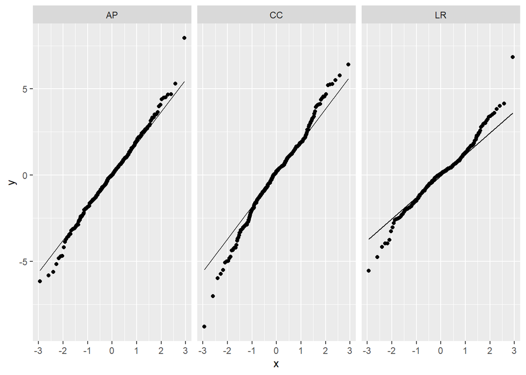

```r
baseline_bladder_results %>%
  purrr::map(~ {.x %>% residuals}) %>%
  bind_rows(.id = "id") %>%
  column_to_rownames("id") %>%
  t() %>%
  data.frame() %>%
  pivot_longer(everything()) %>%
  ggplot(aes(sample = value)) +
  stat_qq() +
  stat_qq_line() +
  facet_wrap(~name, ncol = 3)
```

## Effect of relative bladder

Here we investigate the effect of the relative volume of the bladder on the magnitude of the shift in either direction and location. First we do a plot of Rel_bladder vs shift, and add simple regression lines for each patient/node combination.

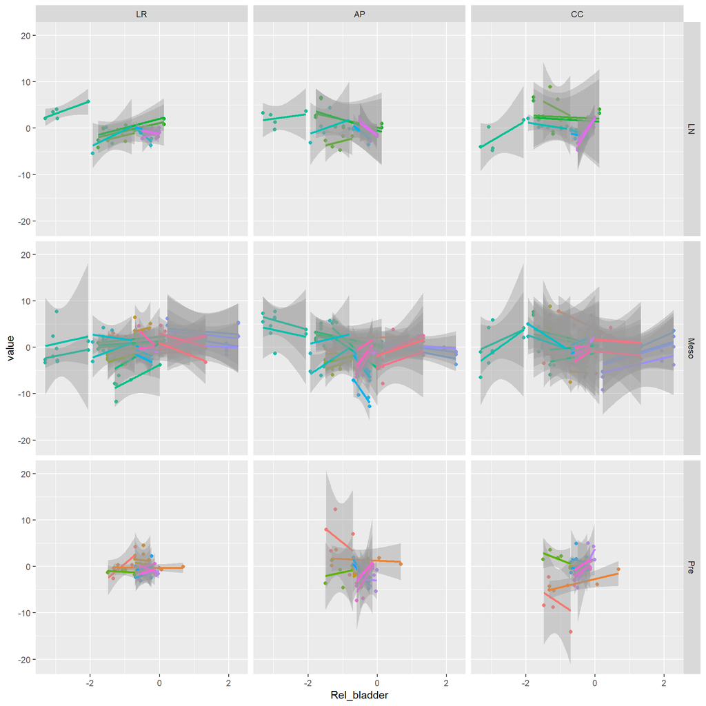

```r
data %>% dplyr::select(Patient, patient_node, Location, Rel_bladder, Shift_LR_GTV:Shift_CC_GTV) %>%
  pivot_longer(cols = Shift_LR_GTV:Shift_CC_GTV) %>%
  mutate(name = factor(sapply(str_split(name, "_"), function(x) x[2]), levels = c("LR", "AP", "CC"))) %>%
  ggplot(aes(x = Rel_bladder, y = value, col = patient_node)) +
  geom_point() +
  stat_smooth(method = "lm",
              formula = y ~ x,
              geom = "smooth") +
  facet_grid(rows = vars(Location), cols = vars(name)) +
  theme(legend.position = "none")
```

We test the effect of the relative fill of the bladder combined and stratified by location and direction using the same nested mixed model as before, i.e. each patient/node gets an indvidual intercept.

```r
#bladder_strat_results <- list()
#for(location in c("LN", "Meso", "Pre")){
#  for(direction in c("LR","AP","CC")){
#    bladder_strat_results[[paste0(location,"_",direction)]] <-
#      lmer(as.formula(paste0("Shift_", direction, "_GTV ~ Rel_bladder + (1|Patient/patient_node)")), data %>% filter(Location == location))
#  }
#}

bladder_strat_results <- list()
for(location in c("Combined", "LN", "Meso", "Pre")){
  for(direction in c("LR","AP","CC")){
    if(location == "Combined"){
      bladder_strat_results[[paste0(location,"_",direction)]] <-
        lmer(as.formula(paste0("Shift_", direction, "_GTV ~ Rel_bladder + (1|Patient/patient_node)")), data)
    } else{
      bladder_strat_results[[paste0(location,"_",direction)]] <-
        lmer(as.formula(paste0("Shift_", direction, "_GTV ~ Rel_bladder + (1|Patient/patient_node)")), data %>% filter(Location == location))
    }
  }
}
```

```r
lapply(bladder_strat_results, broom.mixed::tidy) %>%
  bind_rows(.id = "test") %>%
  filter(term == "Rel_bladder") %>%
  mutate(location = sapply(strsplit(test,"_"), function(x) x[[1]]),
         direction = sapply(strsplit(test,"_"), function(x) x[[2]])) %>%
  dplyr::select(location, direction, estimate, p.value) %>%
  pivot_wider(names_from = "direction", values_from = c("estimate", "p.value")) %>%
  dplyr::select(location, estimate_LR, p.value_LR, estimate_AP, p.value_AP, estimate_CC, p.value_CC) %>%
  kable()
```

| location | estimate_LR | p.value_LR | estimate_AP | p.value_AP | estimate_CC | p.value_CC |
| --- | --- | --- | --- | --- | --- | --- |
| Combined | 0.3769833 | 0.0784180 | -0.6809947 | 0.0138516 | 0.2991526 | 0.3361438 |
| LN | 1.4067589 | 0.0012831 | -1.3309466 | 0.0138977 | 0.7930715 | 0.2468077 |
| Meso | 0.2005602 | 0.4480756 | -0.5287316 | 0.0908914 | -0.0232290 | 0.9448980 |
| Pre | 0.4055876 | 0.4439214 | -1.1283503 | 0.2961191 | 1.4343397 | 0.1161893 |

Model control

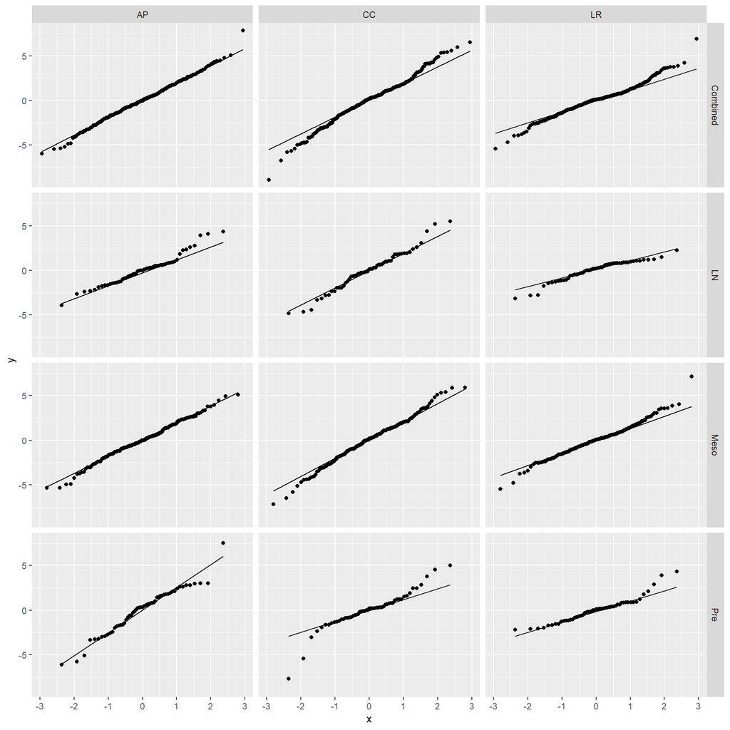

```r
bladder_strat_results %>%
  purrr::map(~ {.x %>% residuals}) %>%
  bind_rows(.id = "id") %>%
  column_to_rownames("id") %>%
  t() %>%
  data.frame() %>%
  pivot_longer(everything()) %>%
  mutate(location = sapply(strsplit(name,"_"), function(x) x[[1]]),
         direction = sapply(strsplit(name,"_"), function(x) x[[2]])) %>%
  ggplot(aes(sample = value)) +
  stat_qq() +
  stat_qq_line() +
  facet_grid(cols = vars(direction), rows = vars(location))
```

## Multivariable model

```r
## model for bladder vs shift with interaction on location. Seems to disrupt the effect on shift_x in pre, seen in the stratified model.
bladder_comb_results <- list()
for(direction in c("LR","AP","CC")){
    bladder_comb_results[[paste0(direction)]] <-
      lmer(as.formula(paste0("Shift_", direction, "_GTV ~ Rel_bladder*Location + Baseline_bladder + `Pretreat/during` + (1|Patient/patient_node)")), data)

}

multires <- lapply(bladder_comb_results, broom.mixed::tidy)
kable(multires$LR, caption = "Results of multivariate model for LR")
```

Results of multivariate model for LR

| effect | group | term | estimate | std.error | statistic | df | p.value |
| --- | --- | --- | --- | --- | --- | --- | --- |
| fixed | NA | (Intercept) | -0.0812829 | 1.2175389 | -0.0667600 | 18.82398 | 0.9474768 |
| fixed | NA | Rel_bladder | 0.5571822 | 0.4653913 | 1.1972339 | 230.69708 | 0.2324442 |
| fixed | NA | LocationMeso | -0.1028153 | 0.7092340 | -0.1449667 | 79.30152 | 0.8851050 |
| fixed | NA | LocationPre | -0.2108367 | 0.8372974 | -0.2518062 | 80.24619 | 0.8018346 |
| fixed | NA | Baseline_bladder | 0.1259385 | 0.5493045 | 0.2292691 | 13.55801 | 0.8220822 |
| fixed | NA | `Pretreat/during`During | -0.0445372 | 0.1972378 | -0.2258045 | 238.00351 | 0.8215473 |
| fixed | NA | Rel_bladder:LocationMeso | -0.2226693 | 0.4760226 | -0.4677703 | 165.27437 | 0.6405651 |
| fixed | NA | Rel_bladder:LocationPre | 0.0022740 | 0.7843740 | 0.0028991 | 274.76641 | 0.9976890 |
| ran_pars | patient_node:Patient | sd__(Intercept) | 1.1322225 | NA | NA | NA | NA |
| ran_pars | Patient | sd__(Intercept) | 1.5251324 | NA | NA | NA | NA |
| ran_pars | Residual | sd__Observation | 1.6587175 | NA | NA | NA | NA |

```r
kable(multires$AP, caption = "Results of multivariate model for AP")
```

Results of multivariate model for AP

| effect | group | term | estimate | std.error | statistic | df | p.value |
| --- | --- | --- | --- | --- | --- | --- | --- |
| fixed | NA | (Intercept) | 0.2569344 | 1.4455307 | 0.1777440 | 22.02002 | 0.8605490 |
| fixed | NA | Rel_bladder | -0.4483474 | 0.5654427 | -0.7929139 | 215.87984 | 0.4286985 |
| fixed | NA | LocationMeso | -1.2396934 | 0.8306429 | -1.4924505 | 76.21745 | 0.1397090 |
| fixed | NA | LocationPre | -0.6231960 | 0.9828147 | -0.6340930 | 79.42560 | 0.5278422 |
| fixed | NA | Baseline_bladder | 0.4187503 | 0.6585909 | 0.6358276 | 16.47529 | 0.5336223 |
| fixed | NA | `Pretreat/during`During | -1.1921816 | 0.2479840 | -4.8074949 | 238.31113 | 0.0000027 |
| fixed | NA | Rel_bladder:LocationMeso | -0.3361974 | 0.5710881 | -0.5886962 | 143.58663 | 0.5569901 |
| fixed | NA | Rel_bladder:LocationPre | -0.9764154 | 0.9619141 | -1.0150754 | 263.27626 | 0.3110018 |
| ran_pars | patient_node:Patient | sd__(Intercept) | 1.2378443 | NA | NA | NA | NA |
| ran_pars | Patient | sd__(Intercept) | 1.8256947 | NA | NA | NA | NA |
| ran_pars | Residual | sd__Observation | 2.0857877 | NA | NA | NA | NA |

```r
kable(multires$CC, caption = "Results of multivariate model for CC")
```

Results of multivariate model for CC

| effect | group | term | estimate | std.error | statistic | df | p.value |
| --- | --- | --- | --- | --- | --- | --- | --- |
| fixed | NA | (Intercept) | -1.3962200 | 1.6291271 | -0.8570357 | 15.38721 | 0.4045759 |
| fixed | NA | Rel_bladder | 0.8306066 | 0.5620517 | 1.4778119 | 182.60204 | 0.1411809 |
| fixed | NA | LocationMeso | 0.0035166 | 0.7368717 | 0.0047723 | 65.06397 | 0.9962069 |
| fixed | NA | LocationPre | 1.1271695 | 0.8792061 | 1.2820310 | 74.73726 | 0.2037944 |
| fixed | NA | Baseline_bladder | 0.6455385 | 0.7835178 | 0.8238977 | 13.32497 | 0.4244997 |
| fixed | NA | `Pretreat/during`During | 0.8873404 | 0.2789002 | 3.1815699 | 240.20608 | 0.0016579 |
| fixed | NA | Rel_bladder:LocationMeso | -0.5764313 | 0.5348672 | -1.0777092 | 92.21149 | 0.2839748 |
| fixed | NA | Rel_bladder:LocationPre | 1.7084852 | 0.9771164 | 1.7484971 | 202.04164 | 0.0818968 |
| ran_pars | patient_node:Patient | sd__(Intercept) | 0.7089587 | NA | NA | NA | NA |
| ran_pars | Patient | sd__(Intercept) | 2.3093311 | NA | NA | NA | NA |
| ran_pars | Residual | sd__Observation | 2.3459189 | NA | NA | NA | NA |